# Trabalho Final

03/12/2019

## Agenda

- Introdução
- Planejamento do Experimento
- Descrição dos Dados
- Análise Exploratória
- Validação das premissas
- Resultados
- Conclusão

## Introdução

### Rotas de produção de aço

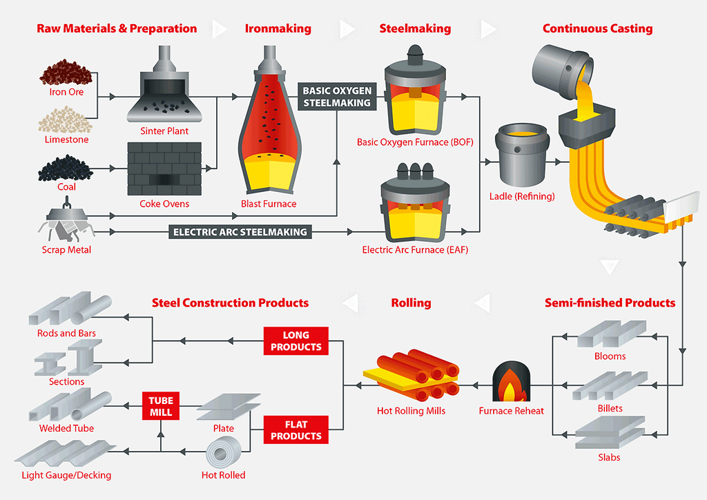

## Introdução

### Processo do Forno Elétrico

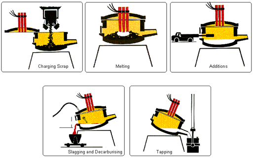

## Descrição dos Dados

- Os dados consistem de KPIs medidos de processo de produção de aço em um forno elétrico, coletados entre Janeiro e Outubro de 2019: consumo de energia elétrica, consumo de oxigênio e tempo de parada.
- Cada instância representa uma execução independente do processo.
- Instâncias consideradas como outliers (erros de medição, valores absurdos) foram removidas
- Os dados foram normalizados por uma constante aleatória, por questões de confidencialidade exigidas para os valores reais

| turma | material | mes | VarConsumo_Quimica | VarConsumo_Eletrica | VarTempoProcesso |
| --- | --- | --- | --- | --- | --- |
| 1 | 2 | 10 | 3.506712 | 13.01872 | 1.69375 |
| 0 | 2 | 10 | 2.945758 | 11.48429 | 1.64750 |
| 1 | 2 | 10 | 3.456152 | 13.85875 | 1.07125 |

## Planejamento do Experimento

### Objetivo

O objetivo é comparar o desempenho das turmas \(T\) em relação aos três KPIs do processo, considerando também diferentes materiais \(M\) produzidos para a comparação.

Portanto, um experimento fatorial será realizado para os fatores **Turma** e **Material**. Além disso, a blocagem será realizada para o fator **Mês**, objetivando remover efeitos de sazonalidade dos dados.

Isso resulta no seguinte modelo linear [1]:

\[\begin{equation}y_{ijk} = \mu + \tau_i + \beta_j + (\tau\beta)_{ij} + \delta_k + \epsilon_{ijk} \end{equation}\]

## Planejamento do Experimento

### Hipóteses

Fator Turma: \[\begin{cases} H_0: \tau_{i} = 0, \forall i &\\H_1:\exists \tau_{i} \neq 0 \end{cases}\]

Fator Material: \[\begin{cases} H_0: \beta_{j} = 0, \forall j &\\H_1:\exists \beta_{j} \neq 0 \end{cases}\] Efeito de interação: \[\begin{cases} H_0: (\tau\beta)_{ij} = 0, \forall i,j &\\H_1:\exists (\tau\beta)_{ij} \neq 0 \end{cases}\]

## Planejamento do Experimento

### Parâmetros experimentais

- Significância desejada: \(\alpha = 0.05\).
- Mínima diferença de importância prática (padronizada): \(d^* = \delta^*/\sigma = 0.3\)
- Potência mínima desejada \(\pi = 1 - \beta = 0.8\)

## Planejamento do Experimento

### Cálculo do número de amostras

| n | ratio | phi |
| --- | --- | --- |
| 14 | 1.9430308 | 5.670 |
| 17 | 1.6103641 | 6.885 |
| 20 | 1.3678672 | 8.100 |
| 23 | 1.1846083 | 9.315 |
| 26 | 1.0419592 | 10.530 |
| 29 | 0.9281759 | 11.745 |
| 32 | 0.8355488 | 12.960 |

## Análise Exploratória

### Número de amostras

| turma/material | 0 | 1 | 2 | 3 | 4 | 5 | 6 | 7 | 13 |
| --- | --- | --- | --- | --- | --- | --- | --- | --- | --- |
| 0 | 187 | 92 | 307 | 89 | 60 | 29 | 153 | 78 | 67 |
| 1 | 113 | 78 | 310 | 87 | 57 | 55 | 154 | 42 | 24 |
| 2 | 167 | 68 | 253 | 71 | 46 | 56 | 201 | 81 | 45 |
| 3 | 178 | 72 | 330 | 69 | 33 | 52 | 143 | 64 | 31 |

## Análise Exploratória

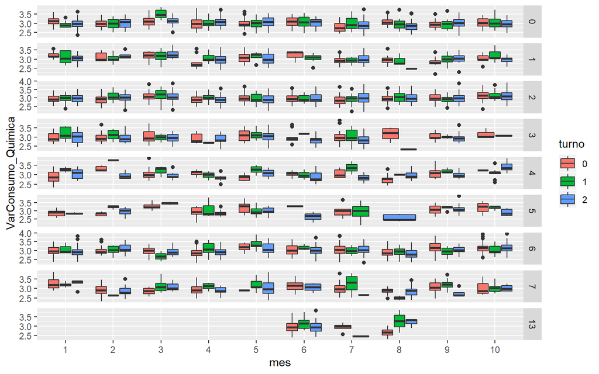

O material 13 será removido por ter sido produzio somente em alguns meses do ano.

## Análise Exploratória

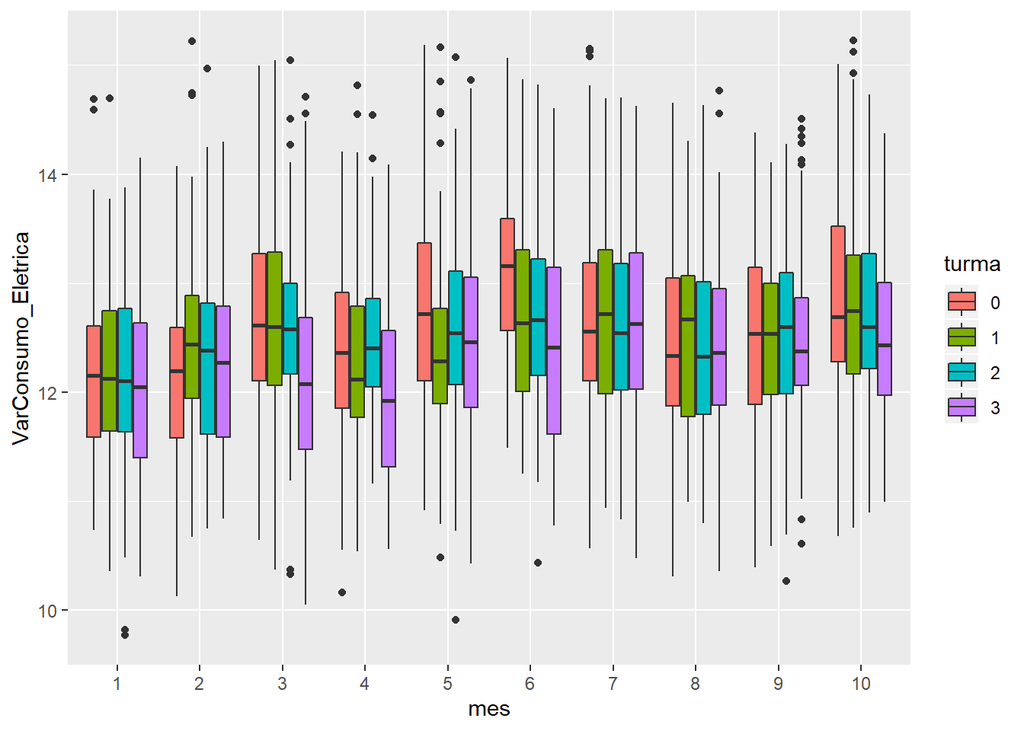

Boxplot da variável elétrica

## Análise Exploratória

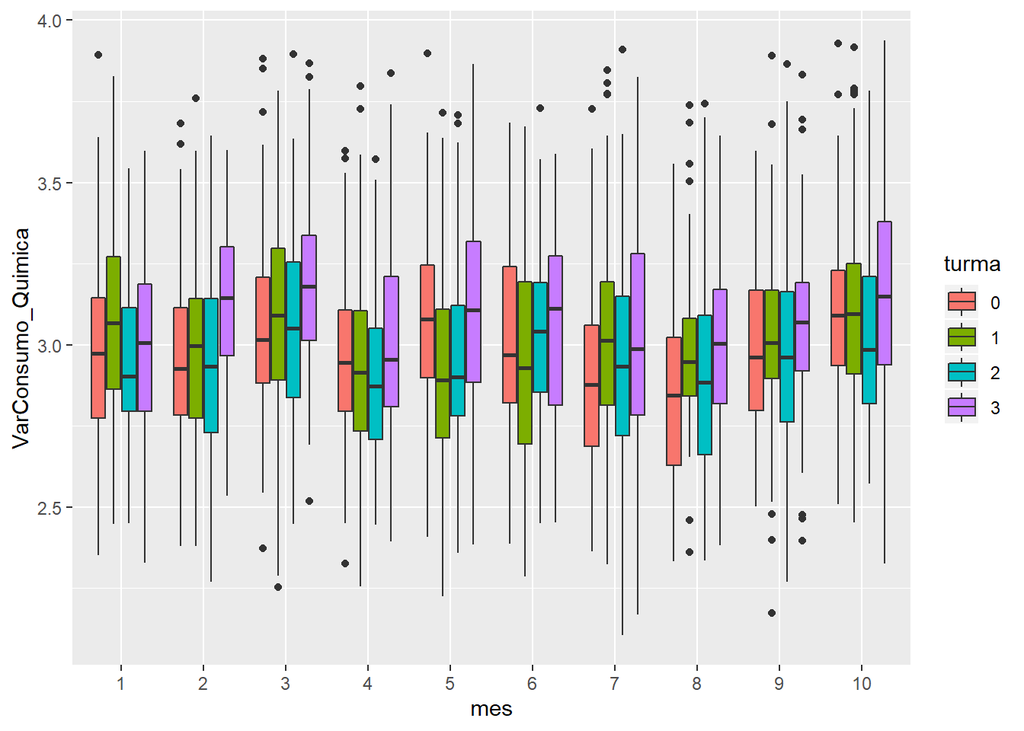

Boxplot da variável química

## Análise Exploratória

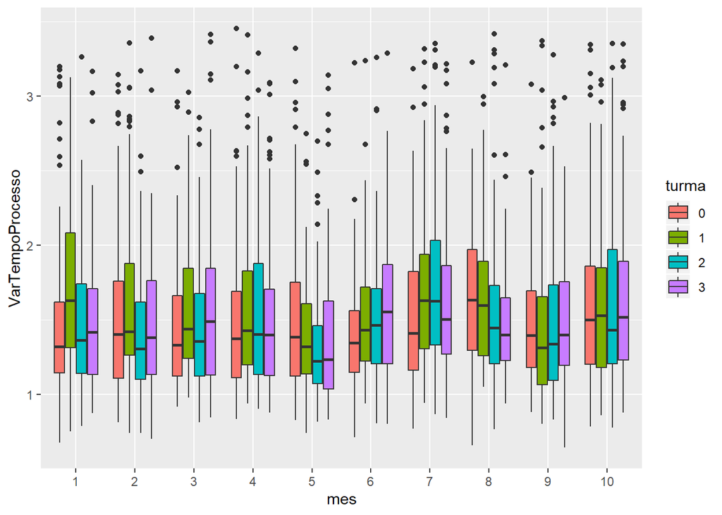

Boxplot do tempo de parada

## Validação das premissas

### Normalidade

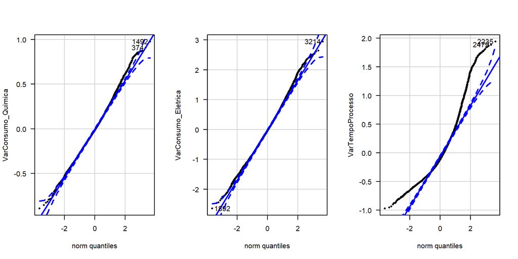

QQ plot para resíduos

## Validação das premissas

### Homocedasticidade

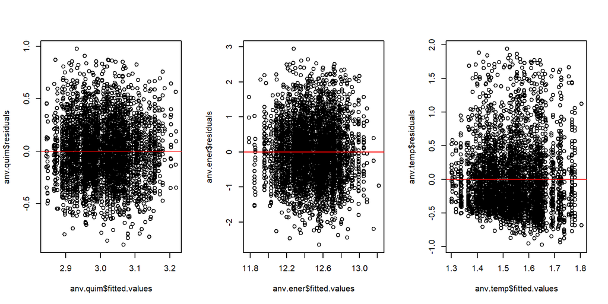

Residuals vs Fitted

## Validação das premissas

### Independência

## Resultados

```r
summary(anv.quim)
```

```
##                  Df Sum Sq Mean Sq F value  Pr(>F)
## mes               9  10.29  1.1431  14.167 < 2e-16 ***
## turma             3   6.68  2.2258  27.586 < 2e-16 ***
## material          7   1.10  0.1567   1.942 0.05917 .
## turma:material   21   3.26  0.1552   1.923 0.00688 **
## Residuals      3734 301.28  0.0807
## ---
## Signif. codes:  0 '***' 0.001 '**' 0.01 '*' 0.05 '.' 0.1 ' ' 1
```

## Resultados

```r
summary(anv.ener)
```

```
##                  Df Sum Sq Mean Sq F value   Pr(>F)
## turma             3   35.3  11.770  16.192 1.87e-10 ***
## material          7   20.8   2.977   4.096 0.000173 ***
## mes               9  146.6  16.293  22.414  < 2e-16 ***
## turma:material   21   18.6   0.885   1.218 0.223912
## Residuals      3734 2714.3   0.727
## ---
## Signif. codes:  0 '***' 0.001 '**' 0.01 '*' 0.05 '.' 0.1 ' ' 1
```

## Resultados

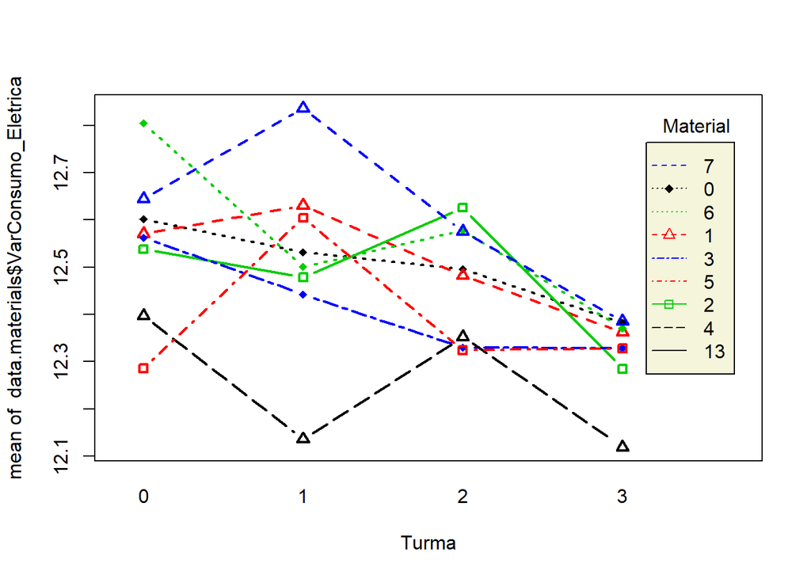

## Resultados

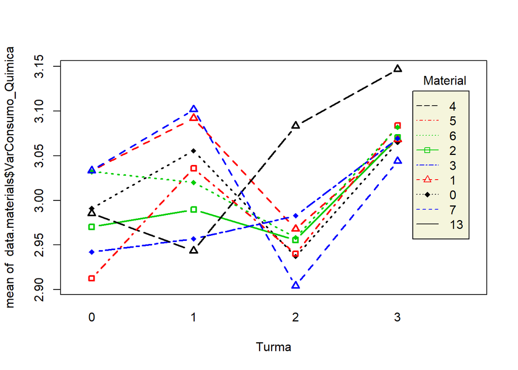

## Resultados

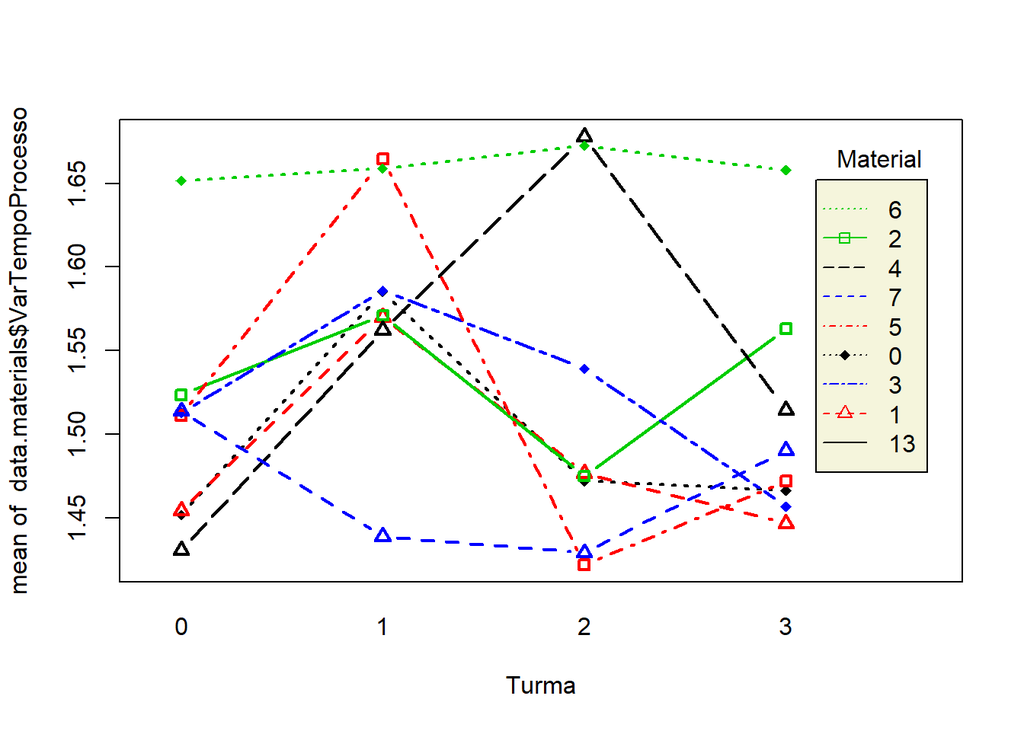

## Resultados

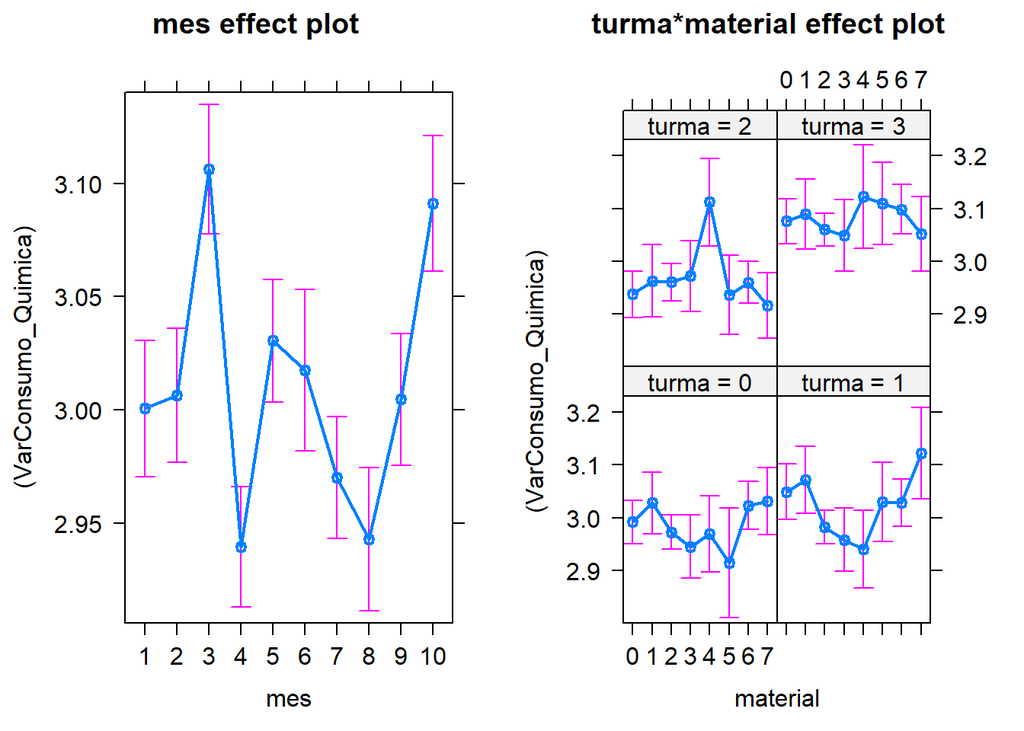

## Resultados

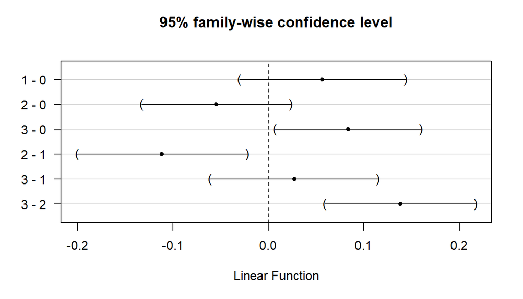

## Resultados

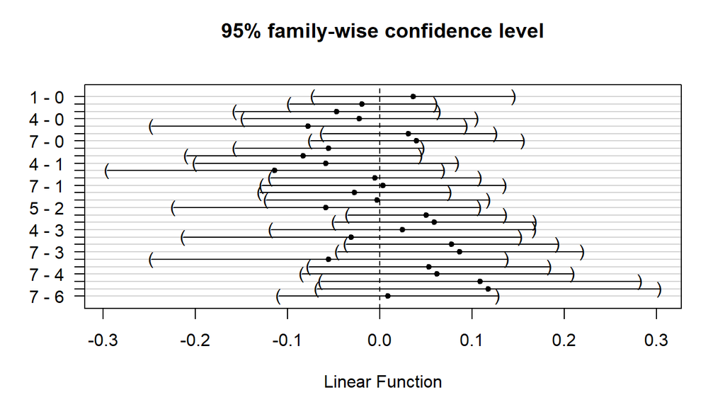

## Resultados

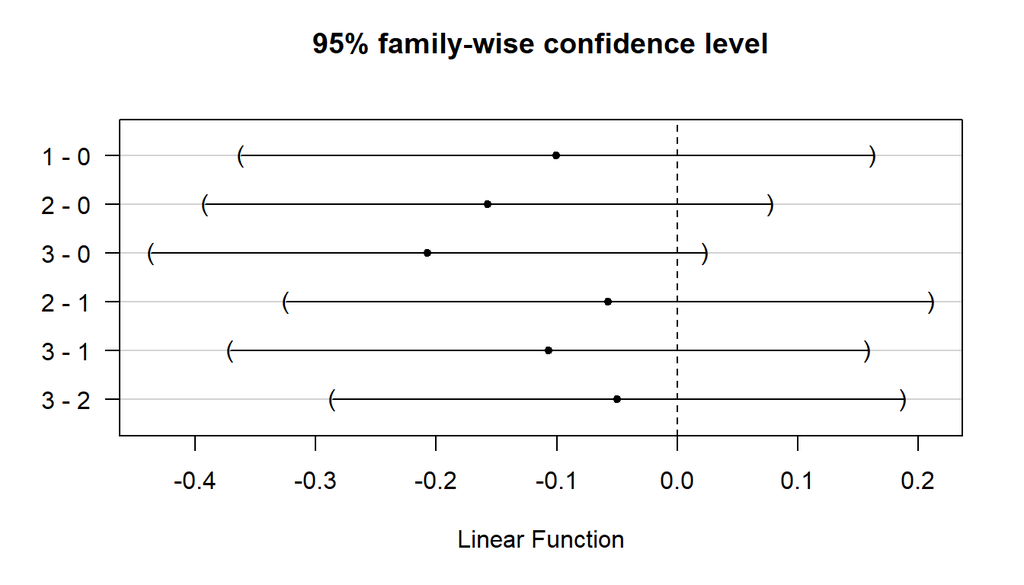

## Resultados

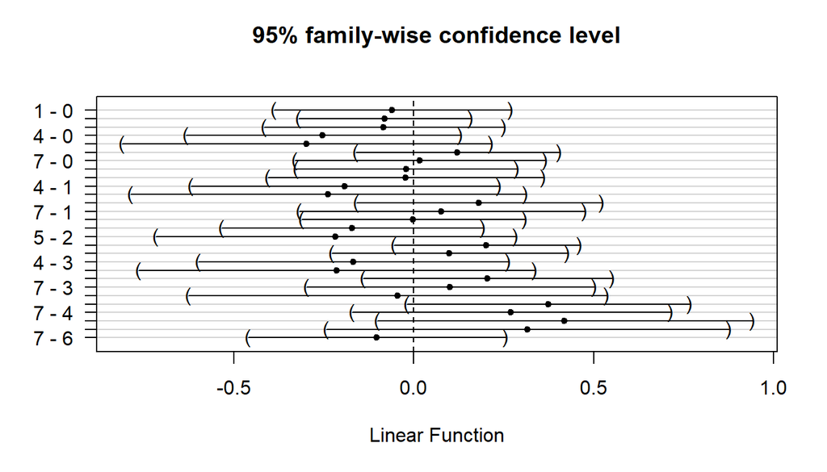

## Conclusão

## Referências

[1] D. C. Montgomery and G. C. Runger, *Applied statistics and probability for engineers, (with cd)*. John Wiley & Sons, 2007.